# Final P3

Jonah Smith

2025-04-18

```r
knitr::opts_chunk$set(echo = TRUE)
```

```r
library(tidyverse)
```

```r
library(coefplot)
library(caret)
library(rstanarm)
library(pROC)
library(broom)
library(glmnet)
library(nnet)
library(tidyr)
library(bayesplot)
## function to be used for feature analysis in the models
plot_top_t_coefs <- function(model, top_n = 10, title = "Top Predictors by |t-value|") {
  broom::tidy(model) %>%
    mutate(t_value = estimate / std.error) %>%
    arrange(desc(abs(t_value))) %>%
    slice(1:top_n) %>%
    ggplot(aes(x = reorder(term, abs(t_value)), y = estimate)) +
    geom_col(fill = "steelblue") +
    geom_errorbar(aes(ymin = estimate - std.error, ymax = estimate + std.error), width = 0.2) +
    coord_flip() +
    labs(title = title,
         x = "Predictor",
         y = "Coefficient Estimate") +
    theme_minimal()
}
```

```r
# Load your training CSV into df so that df %>% mutate() will work
df <- read_csv("paint_project_train_data.csv", col_names = TRUE)
# Prepare classification dataset: include only predictors + the binary outcome
dfiii <- df %>%
  mutate(outcome = factor(outcome)) %>%   # ensure outcome is a factor 0/1
  select(R, G, B, Hue, Lightness, Saturation, outcome)

# 1) Intercept‑only
glm0 <- glm(outcome ~ 1,
            data   = dfiii,
            family = binomial)

# 2) Categorical only
glm_cat <- glm(outcome ~ factor(Lightness) + factor(Saturation),
               data   = dfiii,
               family = binomial)

# 3) Continuous only
glm_cont <- glm(outcome ~ R + G + B + Hue,
                data   = dfiii,
                family = binomial)

# 4) All additive
glm_all <- glm(outcome ~ R + G + B + Hue +
                        factor(Lightness) + factor(Saturation),
               data   = dfiii,
               family = binomial)

# 5) Main‑effects × Categorical interactions
glm_int <- glm(outcome ~ (R + G + B + Hue) *
                        (factor(Lightness) + factor(Saturation)),
               data   = dfiii,
               family = binomial)

# 6) Pairwise continuous + categories
glm_pwcat <- glm(outcome ~ (R + G + B + Hue)^2 +
                           factor(Lightness) + factor(Saturation),
                 data   = dfiii,
                 family = binomial)

# 7) Full pairwise × categories
glm_total <- glm(outcome ~ (R + G + B + Hue)^2 *
                            (factor(Lightness) + factor(Saturation)),
                 data   = dfiii,
                 family = binomial)
```

```
## Warning: glm.fit: fitted probabilities numerically 0 or 1 occurred
```

```r
#MY MODELS
#hue and saturation seem to be the most significant factors in the part 1 analysis for classifying outcome, just include them for a simple model
my_glm_1 <- glm(outcome ~ (Hue) + factor(Saturation),
                data    = dfiii,
                family = binomial)

my_glm_2 <- glm(outcome ~ (Hue) * factor(Saturation),
                data    = dfiii,
                family = binomial)

##consider the circular approach that I used for the regression model in P2. Since it seemed to capture something interesting, we'll try it again here
my_glm_3 <- glm(
  outcome ~ sinpi(Hue/180) + cospi(Hue/180) +
             factor(Saturation) +
             sinpi(Hue/180):factor(Saturation) +
             cospi(Hue/180):factor(Saturation),
  data   = dfiii,
  family = binomial
)

# Summarize all models
###
list(
  intercept_only = summary(glm0),
  categorical    = summary(glm_cat),
  continuous     = summary(glm_cont),
  all_additive   = summary(glm_all),
  interactions   = summary(glm_int),
  pairwise_cat   = summary(glm_pwcat),
  full_model     = summary(glm_total),
  my_glm_1       = summary(my_glm_1),
  my_glm_2       = summary(my_glm_2),
  my_gml_3       = summary(my_glm_3)
)
```

```
## $intercept_only
##
## Call:
## glm(formula = outcome ~ 1, family = binomial, data = dfiii)
##
## Coefficients:
##             Estimate Std. Error z value Pr(>|z|)
## (Intercept) -1.21543    0.08239  -14.75   <2e-16 ***
## ---
## Signif. codes:  0 '***' 0.001 '**' 0.01 '*' 0.05 '.' 0.1 ' ' 1
##
## (Dispersion parameter for binomial family taken to be 1)
##
##     Null deviance: 898.05  on 834  degrees of freedom
## Residual deviance: 898.05  on 834  degrees of freedom
## AIC: 900.05
##
## Number of Fisher Scoring iterations: 4
##
##
## $categorical
##
## Call:
## glm(formula = outcome ~ factor(Lightness) + factor(Saturation),
##     family = binomial, data = dfiii)
##
## Coefficients:
##                            Estimate Std. Error z value Pr(>|z|)
## (Intercept)                 -2.6460     0.4672  -5.664 1.48e-08 ***
## factor(Lightness)deep       -0.6513     0.3551  -1.834  0.06665 .
## factor(Lightness)light      -0.6021     0.3514  -1.714  0.08660 .
## factor(Lightness)midtone    -0.2046     0.3363  -0.608  0.54300
## factor(Lightness)pale       -0.2148     0.3348  -0.642  0.52118
## factor(Lightness)saturated  -0.8739     0.3668  -2.382  0.01721 *
## factor(Lightness)soft       -0.1694     0.3340  -0.507  0.61200
## factor(Saturation)gray       4.2105     0.4943   8.519  < 2e-16 ***
## factor(Saturation)muted      0.5472     0.5337   1.025  0.30521
## factor(Saturation)neutral    2.3742     0.4613   5.147 2.65e-07 ***
## factor(Saturation)pure       1.0741     0.4978   2.158  0.03096 *
## factor(Saturation)shaded     1.8918     0.4681   4.041 5.32e-05 ***
```

[output cut: 450 more lines]

```
## sinpi(Hue/180):factor(Saturation)subdued   -1.997     11.488  -0.174    0.862
## cospi(Hue/180):factor(Saturation)gray     -26.075     37.660  -0.692    0.489
## cospi(Hue/180):factor(Saturation)muted    -30.901     39.238  -0.788    0.431
## cospi(Hue/180):factor(Saturation)neutral    8.492     35.209   0.241    0.809
## cospi(Hue/180):factor(Saturation)pure      -3.131     37.473  -0.084    0.933
## cospi(Hue/180):factor(Saturation)shaded     8.861     35.669   0.248    0.804
## cospi(Hue/180):factor(Saturation)subdued  -16.711     36.184  -0.462    0.644
##
## (Dispersion parameter for binomial family taken to be 1)
##
##     Null deviance: 898.05  on 834  degrees of freedom
## Residual deviance: 706.96  on 814  degrees of freedom
## AIC: 748.96
##
## Number of Fisher Scoring iterations: 6
```

```r
#glimpse(dfiii)
```

I recieved the warning: glm.fit: fitted probabilities numerically 0 or 1 occurred

This essentially means that the models start to predict so large a probability that it will essentially over or underflow to 0 or 1. I think this is to be expected when we have models with this complexity.

```r
# 1) Build a tibble of true labels + predicted probabilities
prob_df <- tibble(
  true          = dfiii$outcome,
  intercept     = predict(glm0,         type = "response"),
  categorical   = predict(glm_cat,      type = "response"),
  continuous    = predict(glm_cont,     type = "response"),
  all_additive  = predict(glm_all,      type = "response"),
  interactions  = predict(glm_int,      type = "response"),
  pairwise_cat  = predict(glm_pwcat,    type = "response"),
  full_model    = predict(glm_total,    type = "response"),
  my_glm_1      = predict(my_glm_1,     type = "response"),
  my_glm_2      = predict(my_glm_2,     type = "response"),
  my_glm_3      = predict(my_glm_3,     type = "response"),
)

# 2) Compute ROC coordinates for each model
roc_list <- lapply(names(prob_df)[-1], function(m) {
  roc_obj   <- roc(prob_df$true, prob_df[[m]])
  coords_df <- coords(roc_obj, "all",
                     ret = c("specificity","sensitivity"),
                     transpose = FALSE)
  tibble(model       = m,
         specificity = coords_df$specificity,
         sensitivity = coords_df$sensitivity)
})
```

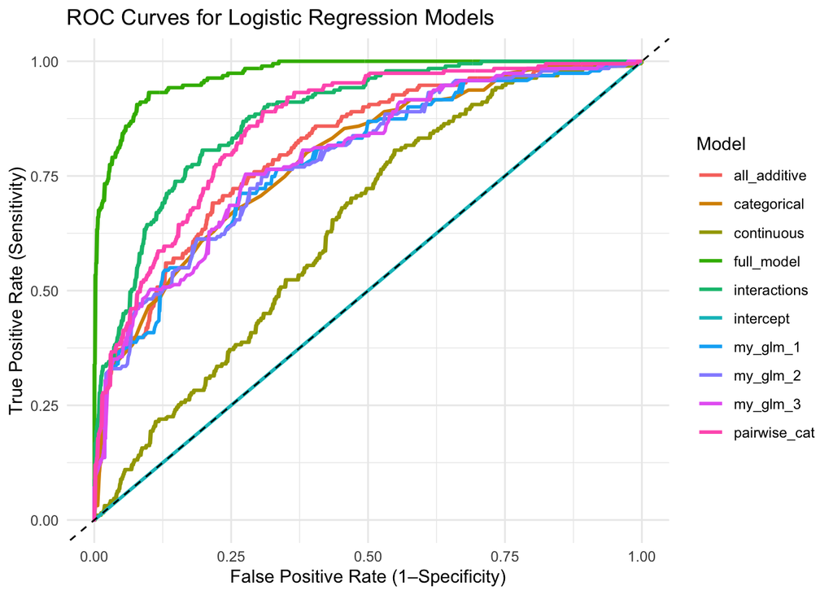

```r
roc_df <- bind_rows(roc_list) %>%
  mutate(fpr = 1 - specificity)

# 3) Plot them with ggplot2
ggplot(roc_df, aes(x = fpr, y = sensitivity, color = model)) +
  geom_line(size = 1) +
  geom_abline(linetype = "dashed") +
  scale_x_continuous("False Positive Rate (1–Specificity)", limits = c(0,1)) +
  scale_y_continuous("True Positive Rate (Sensitivity)",   limits = c(0,1)) +
  labs(title = "ROC Curves for Logistic Regression Models",
       color = "Model") +
  theme_minimal()
```

```r
# 4) Rank models by AUC
model_list <- list(
  intercept     = glm0,
  categorical   = glm_cat,
  continuous    = glm_cont,
  all_additive  = glm_all,
  interactions  = glm_int,
  pairwise_cat  = glm_pwcat,
  full_model    = glm_total,
  my_glm_1      = my_glm_1,
  my_glm_2      = my_glm_2,
  my_glm_3      = my_glm_3
)

auc_df <- tibble(
  model = names(model_list),
  AUC   = sapply(model_list, function(m) {
    roc_obj <- roc(dfiii$outcome, predict(m, type="response"))
    as.numeric(auc(roc_obj))
  })
) %>%
  arrange(desc(AUC))
print(auc_df)
```

```
## # A tibble: 10 × 2
##    model          AUC
##    <chr>        <dbl>
##  1 full_model   0.971
##  2 interactions 0.880
##  3 pairwise_cat 0.859
##  4 all_additive 0.809
##  5 my_glm_3     0.793
##  6 categorical  0.790
##  7 my_glm_2     0.786
##  8 my_glm_1     0.783
##  9 continuous   0.641
## 10 intercept    0.5
```

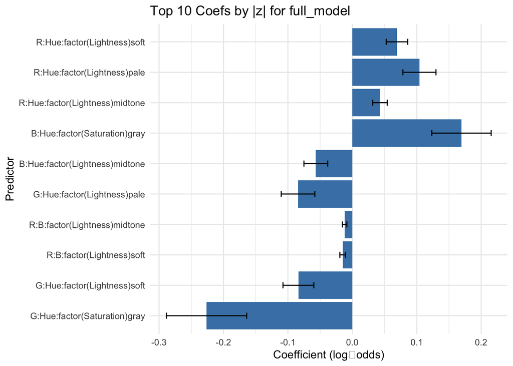

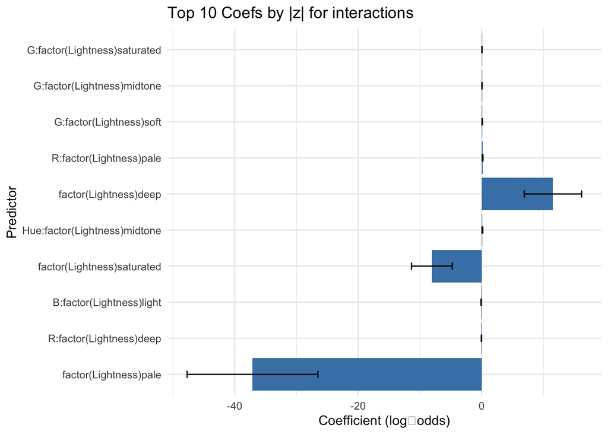

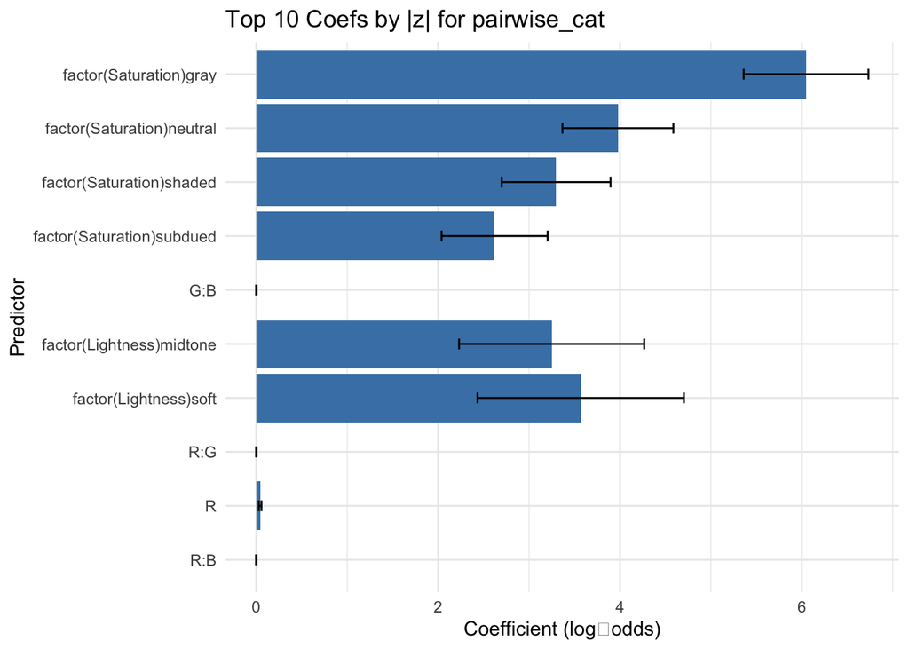

```r
# 5) Plot top‐10 coefficients (by |z|) for the top 3 models
plot_top_z_coefs <- function(mod, top_n = 10, title = "") {
  tidy(mod) %>%
    mutate(z_value = estimate / std.error) %>%
    arrange(desc(abs(z_value))) %>%
    slice(1:top_n) %>%
    ggplot(aes(x = reorder(term, z_value), y = estimate)) +
      geom_col(fill = "steelblue") +
      geom_errorbar(aes(
        ymin = estimate - std.error,
        ymax = estimate + std.error
      ), width = 0.2) +
      coord_flip() +
      labs(
        title = title,
        x = "Predictor",
        y = "Coefficient (log‑odds)"
      ) +
      theme_minimal()
}

top3 <- auc_df$model[1:3]

for (m in top3) {
  print(plot_top_z_coefs(
    model_list[[m]],
    top_n = 10,
    title = paste("Top 10 Coefs by |z| for", m)
  ))
}
```

The factors seem important here as well (similar to the regression model). Some of the colors seemed to be important in terms of their interactions with other features. The only continuous feature that sits in the top 10 alone is R for any of the models. The key takeaway is that the categorical features are consistently significant in the classification model.